# Control Structures and Error handling on the airquality dataset

Josue Iraduknda

2026-11-01

# Introduction

**Control structures** decide *which* code runs and *how many times*. In data management they are how you:

- check data quality before processing (`if` / `else`),
- create new categorical variables from numeric ones (`ifelse`, `switch`),
- repeat the same cleaning step on many columns, months or groups (`for`),
- skip or stop early when something is wrong (`next`, `break`),
- keep going until a condition is met, e.g. until no outliers remain (`while`, `repeat`),
- handle failures gracefully (`stop`, `warning`, `tryCatch`).

# The dataset: `airquality`

`airquality` contains daily air quality measurements in New York, May to September 1973 (153 rows). It is useful here because it has **missing values** in `Ozone` and `Solar.R`.

| Variable \| | Description \| |
| --- | --- |
| `Ozone` | Mean ozone (ppb) |
| `Solar.R` | Solar radiation (langleys) |
| `Wind` | Average wind speed (mph) |
| `Temp` | Maximum daily temperature (°F) |
| `Month` | Month (5 to 9) |
| `Day` | Day of month |

```r
aq <- airquality          # work on a copy; never modify the original
str(aq)
```

```
## 'data.frame':    153 obs. of  6 variables:
##  $ Ozone  : int  41 36 12 18 NA 28 23 19 8 NA ...
##  $ Solar.R: int  190 118 149 313 NA NA 299 99 19 194 ...
##  $ Wind   : num  7.4 8 12.6 11.5 14.3 14.9 8.6 13.8 20.1 8.6 ...
##  $ Temp   : int  67 72 74 62 56 66 65 59 61 69 ...
##  $ Month  : int  5 5 5 5 5 5 5 5 5 5 ...
##  $ Day    : int  1 2 3 4 5 6 7 8 9 10 ...
```

```r
head(aq, 10)
```

```
##    Ozone Solar.R Wind Temp Month Day
## 1     41     190  7.4   67     5   1
## 2     36     118  8.0   72     5   2
## 3     12     149 12.6   74     5   3
## 4     18     313 11.5   62     5   4
## 5     NA      NA 14.3   56     5   5
## 6     28      NA 14.9   66     5   6
## 7     23     299  8.6   65     5   7
## 8     19      99 13.8   59     5   8
## 9      8      19 20.1   61     5   9
## 10    NA     194  8.6   69     5  10
```

```r
summary(aq)
```

```
##      Ozone           Solar.R           Wind             Temp
##  Min.   :  1.00   Min.   :  7.0   Min.   : 1.700   Min.   :56.00
##  1st Qu.: 18.00   1st Qu.:115.8   1st Qu.: 7.400   1st Qu.:72.00
##  Median : 31.50   Median :205.0   Median : 9.700   Median :79.00
##  Mean   : 42.13   Mean   :185.9   Mean   : 9.958   Mean   :77.88
##  3rd Qu.: 63.25   3rd Qu.:258.8   3rd Qu.:11.500   3rd Qu.:85.00
##  Max.   :168.00   Max.   :334.0   Max.   :20.700   Max.   :97.00
##  NAs    :37       NAs    :7
##      Month            Day
##  Min.   :5.000   Min.   : 1.0
##  1st Qu.:6.000   1st Qu.: 8.0
##  Median :7.000   Median :16.0
##  Mean   :6.993   Mean   :15.8
##  3rd Qu.:8.000   3rd Qu.:23.0
##  Max.   :9.000   Max.   :31.0
##
```

```r
colSums(is.na(aq))
```

```
##   Ozone Solar.R    Wind    Temp   Month     Day
##      37       7       0       0       0       0
```

```r
round(colMeans(is.na(aq)) * 100, 1)   # % missing per column
```

```
##   Ozone Solar.R    Wind    Temp   Month     Day
##    24.2     4.6     0.0     0.0     0.0     0.0
```

# Conditional statements: `if`, `else if`, `else`

## Basic syntax

```r
if (condition) {
  # runs when condition is TRUE
} else if (other_condition) {
  # runs when the first is FALSE and this is TRUE
} else {
  # runs otherwise
}
```

The `condition` must be a **single** `TRUE` or `FALSE` (a length-one logical). `NA` causes an error.

## A data-quality check

```r
n_missing <- sum(is.na(aq$Ozone))

if (n_missing > 0) {
  cat("Ozone has", n_missing, "missing values (",
      round(100 * n_missing / nrow(aq), 1), "%).\n")
} else {
  cat("Ozone is complete.\n")
}
```

```
## Ozone has 37 missing values ( 24.2 %).
```

## Several branches in a function

```r
classify_temp <- function(t) {
  if (is.na(t)) {
    "Missing"
  } else if (t < 60) {
    "Cold"
  } else if (t < 80) {
    "Mild"
  } else {
    "Hot"
  }
}

classify_temp(aq$Temp[1])    # 67
```

```
## [1] "Mild"
```

```r
classify_temp(95)
```

```
## [1] "Hot"
```

```r
classify_temp(NA)
```

```
## [1] "Missing"
```

## Logical operators in conditions: `&&`, `||` vs `&`, `|`

- `&&` and `||` work on **single** values and short-circuit (the right side is skipped if the left decides the answer). Use them inside `if`.
- `&` and `|` work **element-wise** on vectors. Use them for filtering.

```r
x <- aq$Ozone[1:6]
x
```

```
## [1] 41 36 12 18 NA 28
```

```r
# Element-wise: returns a vector
x > 20 & !is.na(x)
```

```
## [1]  TRUE  TRUE FALSE FALSE FALSE  TRUE
```

```r
# Short-circuit: single TRUE/FALSE, safe from NA problems
val <- aq$Ozone[5]               # NA
if (!is.na(val) && val > 50) "high" else "not high / missing"
```

```
## [1] "not high / missing"
```

## Common pitfall: `if` on a vector

Since R 4.2, giving `if` a condition longer than one is an **error**. Collapse the condition with `any()`, `all()` or use `ifelse()`.

```r
res <- tryCatch(
  if (aq$Temp > 80) "hot",
  error = function(e) conditionMessage(e)
)
res
```

```
## [1] "the condition has length > 1"
```

```r
# Correct: ask a single question about the whole vector
if (any(aq$Temp > 95)) cat("At least one day exceeded 95F\n")
```

```
## At least one day exceeded 95F
```

```r
if (all(aq$Temp > 50))  cat("All days were above 50F\n")
```

```
## All days were above 50F
```

## Useful condition helpers

```r
is.na(c(1, NA, 3))
```

```
## [1] FALSE  TRUE FALSE
```

```r
anyNA(aq$Ozone)
```

```
## [1] TRUE
```

```r
isTRUE(all(aq$Month %in% 5:9))      # isTRUE() guards against NA
```

```
## [1] TRUE
```

```r
is.numeric(aq$Temp)
```

```
## [1] TRUE
```

```r
is.null(NULL)
```

```
## [1] TRUE
```

## Validate a data frame before working on it

```r
validate_airquality <- function(df) {
  required <- c("Ozone", "Solar.R", "Wind", "Temp", "Month", "Day")

  if (!is.data.frame(df)) {
    stop("Input must be a data frame.")
  }
  if (!all(required %in% names(df))) {
    missing_cols <- setdiff(required, names(df))
    stop("Missing columns: ", paste(missing_cols, collapse = ", "))
  }
  if (nrow(df) == 0) {
    warning("Data frame has zero rows.")
    return(FALSE)
  }
  TRUE
}

validate_airquality(aq)
```

```
## [1] TRUE
```

```r
tryCatch(validate_airquality(aq[, 1:3]),
         error = function(e) cat("Validation failed:", conditionMessage(e), "\n"))
```

```
## Validation failed: Missing columns: Temp, Month, Day
```

# Vectorised conditionals: `ifelse()`

`ifelse(test, yes, no)` evaluates `test` for **every element** and picks `yes` or `no` for each. It is the standard way to create a new column from a condition.

## Create a categorical variable

```r
aq$Temp_cat <- ifelse(aq$Temp < 60, "Cold",
                ifelse(aq$Temp < 80, "Mild", "Hot"))

table(aq$Temp_cat)
```

```
##
## Cold  Hot Mild
##    8   73   72
```

```r
head(aq[, c("Temp", "Temp_cat")])
```

```
##   Temp Temp_cat
## 1   67     Mild
## 2   72     Mild
## 3   74     Mild
## 4   62     Mild
## 5   56     Cold
## 6   66     Mild
```

## Flag missing values

```r
aq$Ozone_missing <- ifelse(is.na(aq$Ozone), "Missing", "Observed")
table(aq$Ozone_missing, aq$Month)
```

```
##
##             5  6  7  8  9
##   Missing   5 21  5  5  1
##   Observed 26  9 26 26 29
```

## `ifelse()` and `NA`

`NA` in the test gives `NA` in the output. Handle it explicitly:

```r
aq$Ozone_level <- ifelse(is.na(aq$Ozone), "Unknown",
                   ifelse(aq$Ozone > 70, "High",
                    ifelse(aq$Ozone > 30, "Moderate", "Low")))
table(aq$Ozone_level)
```

```
##
##     High      Low Moderate  Unknown
##       25       57       34       37
```

## Alternative for many break points: `cut()`

Deeply nested `ifelse()` calls get hard to read. For numeric ranges, `cut()` is cleaner:

```r
aq$Temp_cut <- cut(aq$Temp,
                   breaks = c(-Inf, 60, 80, Inf),
                   labels = c("Cold", "Mild", "Hot"),
                   right  = FALSE)         # intervals are [a, b)
table(aq$Temp_cut)
```

```
##
## Cold Mild  Hot
##    8   72   73
```

```r
# Same answer as the nested ifelse
identical(as.character(aq$Temp_cut), aq$Temp_cat)
```

```
## [1] TRUE
```

## Conditional subsetting: logical filters and `which()`

```r
# Days with ozone above 100 ppb (exclude NA explicitly)
high_ozone <- aq[!is.na(aq$Ozone) & aq$Ozone > 100,
                 c("Ozone", "Temp", "Wind", "Month", "Day")]
high_ozone
```

```
##     Ozone Temp Wind Month Day
## 30    115   79  5.7     5  30
## 62    135   84  4.1     7   1
## 86    108   85  8.0     7  25
## 99    122   89  4.0     8   7
## 101   110   90  8.0     8   9
## 117   168   81  3.4     8  25
## 121   118   94  2.3     8  29
```

```r
# which() ignores NA and returns row positions
which(aq$Ozone > 100)
```

```
## [1]  30  62  86  99 101 117 121
```

```r
# Without handling NA, the filter produces junk "NA rows"
nrow(aq[aq$Ozone > 100, ])               # includes NA rows!
```

```
## [1] 44
```

```r
nrow(aq[which(aq$Ozone > 100), ])        # correct
```

```
## [1] 7
```

```r
# subset() drops NA tests automatically
nrow(subset(aq, Ozone > 100 & Month == 8))
```

```
## [1] 4
```

# Choosing among alternatives: `switch()`

`switch(EXPR, name1 = value1, name2 = value2, ..., default)` picks the branch whose name matches the string `EXPR`. If no name matches, the unnamed last argument is returned as a default.

## A function that selects a statistic by name

```r
describe_col <- function(x, stat = "mean") {
  switch(stat,
    mean   = mean(x, na.rm = TRUE),
    median = median(x, na.rm = TRUE),
    sd     = sd(x, na.rm = TRUE),
    range  = ,                                   # fall-through: same as next line
    spread = diff(range(x, na.rm = TRUE)),
    stop("Unknown statistic: '", stat, "'")      # default
  )
}

describe_col(aq$Temp, "mean")
```

```
## [1] 77.88235
```

```r
describe_col(aq$Temp, "median")
```

```
## [1] 79
```

```r
describe_col(aq$Temp, "range")      # falls through to "spread"
```

```
## [1] 41
```

```r
tryCatch(describe_col(aq$Temp, "mode"),
         error = function(e) conditionMessage(e))
```

```
## [1] "Unknown statistic: 'mode'"
```

## Recoding labels: months to periods

`switch()` handles a **single** value, so to recode a whole column, combine it with `sapply()` / `vapply()`:

```r
month_to_period <- function(m) {
  switch(as.character(m),
         "5" = ,
         "6" = "Early summer",
         "7" = ,
         "8" = "Peak summer",
         "9" = "Late summer",
         NA_character_)
}

aq$Period <- vapply(aq$Month, month_to_period, FUN.VALUE = character(1))
table(aq$Month, aq$Period)
```

```
##
##     Early summer Late summer Peak summer
##   5           31           0           0
##   6           30           0           0
##   7            0           0          31
##   8            0           0          31
##   9            0          30           0
```

## Numeric `switch()`

When `EXPR` is a number, it selects by position:

```r
switch(2, "first", "second", "third")
```

```
## [1] "second"
```

(This is less readable and less safe than named alternatives. Prefer strings.)

# Loops: `for`

## Loop over columns: missing-value report

```r
for (col in names(airquality)) {
  n_na <- sum(is.na(airquality[[col]]))
  cat(sprintf("%-8s | missing: %3d | %5.1f%%\n",
              col, n_na, 100 * n_na / nrow(airquality)))
}
```

```
## Ozone    | missing:  37 |  24.2%
## Solar.R  | missing:   7 |   4.6%
## Wind     | missing:   0 |   0.0%
## Temp     | missing:   0 |   0.0%
## Month    | missing:   0 |   0.0%
## Day      | missing:   0 |   0.0%
```

## Pre-allocate results, then fill

Growing a vector inside a loop (`x <- c(x, new)`) is slow. Create the container first.

```r
vars <- c("Ozone", "Solar.R", "Wind", "Temp")

col_means <- numeric(length(vars))
names(col_means) <- vars

for (i in seq_along(vars)) {
  col_means[i] <- mean(airquality[[vars[i]]], na.rm = TRUE)
}
round(col_means, 2)
```

```
##   Ozone Solar.R    Wind    Temp
##   42.13  185.93    9.96   77.88
```

## Loop over rows: classification

```r
comfort <- character(nrow(aq))      # pre-allocate

for (i in seq_len(nrow(aq))) {
  t <- aq$Temp[i]
  w <- aq$Wind[i]

  comfort[i] <- if (t >= 80 && w < 8) {
    "Hot and stuffy"
  } else if (t >= 80) {
    "Hot and breezy"
  } else if (t < 60) {
    "Cold"
  } else {
    "Comfortable"
  }
}

aq$Comfort <- comfort
table(aq$Comfort)
```

```
##
##           Cold    Comfortable Hot and breezy Hot and stuffy
##              8             72             44             29
```

## Nested loops: a month by variable summary matrix

```r
months <- sort(unique(aq$Month))

summary_mat <- matrix(NA_real_,
                      nrow = length(months), ncol = length(vars),
                      dimnames = list(month.abb[months], vars))

for (m in months) {
  for (v in vars) {
    summary_mat[month.abb[m], v] <- mean(aq[aq$Month == m, v], na.rm = TRUE)
  }
}
round(summary_mat, 1)
```

```
##     Ozone Solar.R Wind Temp
## May  23.6   181.3 11.6 65.5
## Jun  29.4   190.2 10.3 79.1
## Jul  59.1   216.5  8.9 83.9
## Aug  60.0   171.9  8.8 84.0
## Sep  31.4   167.4 10.2 76.9
```

## Loop over a list of data frames (split by group)

```r
by_month <- split(aq, aq$Month)

results <- vector("list", length(by_month))
names(results) <- paste0("Month_", names(by_month))

for (nm in names(by_month)) {
  d <- by_month[[nm]]
  results[[paste0("Month_", nm)]] <- data.frame(
    month      = as.integer(nm),
    n_days     = nrow(d),
    max_temp   = max(d$Temp),
    mean_ozone = round(mean(d$Ozone, na.rm = TRUE), 1),
    pct_na     = round(100 * mean(is.na(d$Ozone)), 1)
  )
}

monthly_report <- do.call(rbind, results)
rownames(monthly_report) <- NULL
monthly_report
```

```
##   month n_days max_temp mean_ozone pct_na
## 1     5     31       81       23.6   16.1
## 2     6     30       93       29.4   70.0
## 3     7     31       92       59.1   16.1
## 4     8     31       97       60.0   16.1
## 5     9     30       93       31.4    3.3
```

## Visualising the loop result

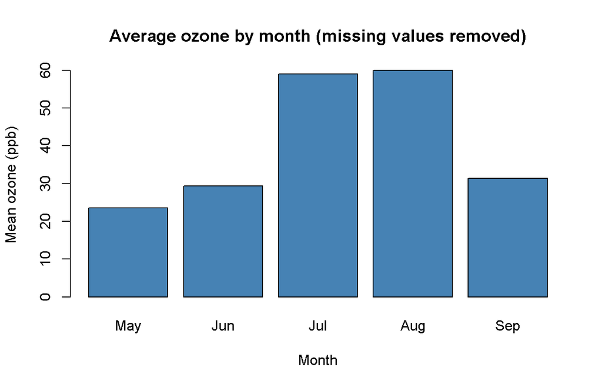

```r
barplot(monthly_report$mean_ozone,
        names.arg = month.abb[monthly_report$month],
        col = "steelblue", xlab = "Month", ylab = "Mean ozone (ppb)",
        main = "Average ozone by month (missing values removed)")
```

# Controlling loops: `next` and `break`

- `next` skips the rest of the current iteration and moves on.
- `break` leaves the loop entirely.

## `next`: skip columns that don’t qualify

```r
# Add a text column and a logical column so the data is of mixed type
mixed <- transform(airquality, Station = "NYC", Rainy = Wind > 12)

for (col in names(mixed)) {
  if (!is.numeric(mixed[[col]])) {
    cat("Skipping non-numeric column:", col, "\n")
    next
  }
  if (!anyNA(mixed[[col]])) next          # nothing to report

  cat("Column", col, "has", sum(is.na(mixed[[col]])), "missing values\n")
}
```

```
## Column Ozone has 37 missing values
## Column Solar.R has 7 missing values
## Skipping non-numeric column: Station
## Skipping non-numeric column: Rainy
```

## `break`: stop at the first match

```r
first_high <- NA_integer_

for (i in seq_len(nrow(aq))) {
  if (is.na(aq$Ozone[i])) next            # ignore missing readings
  if (aq$Ozone[i] > 100) {
    first_high <- i
    break                                  # no need to look further
  }
}

first_high
```

```
## [1] 30
```

```r
aq[first_high, c("Ozone", "Temp", "Month", "Day")]
```

```
##    Ozone Temp Month Day
## 30   115   79     5  30
```

## `next` and `break` together: build a data-quality log

```r
log_entries <- character(0)

for (col in names(airquality)) {
  x <- airquality[[col]]
  pct <- 100 * mean(is.na(x))

  if (pct == 0) next                                  # clean column, move on
  log_entries <- c(log_entries,
                   sprintf("%s: %.1f%% missing", col, pct))

  if (pct > 50) {                                     # unusable: stop the audit
    log_entries <- c(log_entries, "STOP: more than half missing")
    break
  }
}
log_entries
```

```
## [1] "Ozone: 24.2% missing"  "Solar.R: 4.6% missing"
```

# Loops with conditions: `while` and `repeat`

## `while`: repeat as long as a condition holds

### Accumulate until a threshold

```r
threshold <- 2000
i <- 0
total <- 0

while (total < threshold && i < nrow(aq)) {
  i <- i + 1
  if (!is.na(aq$Ozone[i])) total <- total + aq$Ozone[i]
}

cat("Cumulative ozone first exceeded", threshold, "after", i, "days (total =", total, ")\n")
```

```
## Cumulative ozone first exceeded 2000 after 86 days (total = 2089 )
```

```r
cat("That is", format(as.Date(sprintf("1973-%02d-%02d", aq$Month[i], aq$Day[i])), "%d %B"), "\n")
```

```
## That is 25 July
```

### Iterative outlier removal

Removing outliers changes the mean and standard deviation, which can expose new outliers. A `while` loop repeats until the data is stable.

```r
x <- aq$Ozone[!is.na(aq$Ozone)]
n_start <- length(x)
iteration <- 0

while (length(x) > 5 && any(abs(x - mean(x)) > 2.5 * sd(x))) {
  keep <- abs(x - mean(x)) <= 2.5 * sd(x)
  cat(sprintf("Iteration %d: removing %d value(s)\n", iteration + 1, sum(!keep)))
  x <- x[keep]
  iteration <- iteration + 1
}
```

```
## Iteration 1: removing 2 value(s)
## Iteration 2: removing 3 value(s)
## Iteration 3: removing 2 value(s)
```

```r
cat("Started with", n_start, "values, finished with", length(x),
    "after", iteration, "iteration(s)\n")
```

```
## Started with 116 values, finished with 109 after 3 iteration(s)
```

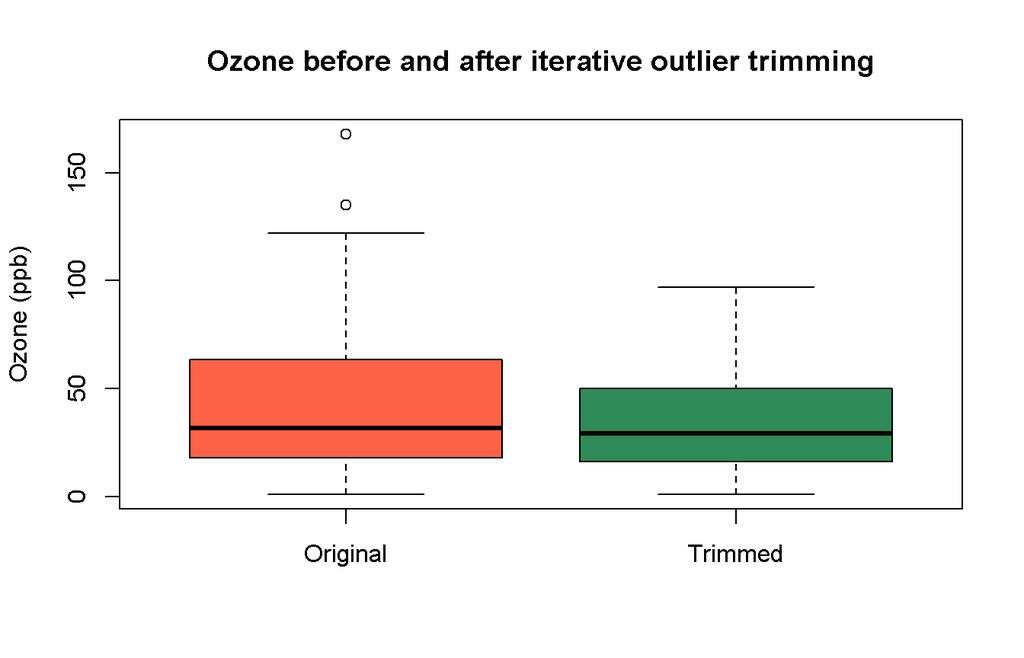

```r
boxplot(list(Original = aq$Ozone, Trimmed = x),
        col = c("tomato", "seagreen"), ylab = "Ozone (ppb)",
        main = "Ozone before and after iterative outlier trimming")
```

## `repeat`: loop forever until `break`

```r
set.seed(123)
target   <- mean(aq$Temp)
attempts <- 0

repeat {
  attempts <- attempts + 1
  s <- sample(aq$Temp, size = 20)

  if (abs(mean(s) - target) < 0.5) break          # success

  if (attempts >= 1000) {                          # safety valve
    warning("No acceptable sample found")
    break
  }
}

cat("Found a representative sample of 20 days after", attempts, "attempt(s)\n")
```

```
## Found a representative sample of 20 days after 6 attempt(s)
```

```r
cat("Population mean:", round(target, 2), "| sample mean:", round(mean(s), 2), "\n")
```

```
## Population mean: 77.88 | sample mean: 77.4
```

> **Always include a safety valve** (maximum iterations) in `while` / `repeat` loops that depend on data to avoid infinite loops.

# Handling problems: `stop()`, `warning()`, `tryCatch()`

Control flow is also about what happens when something goes wrong.

```r
safe_mean <- function(x) {
  tryCatch({
    if (!is.numeric(x)) stop("input is not numeric")
    if (all(is.na(x)))  warning("all values are NA")
    mean(x, na.rm = TRUE)
  },
  warning = function(w) {
    cat("  Warning caught:", conditionMessage(w), "\n")
    NA_real_
  },
  error = function(e) {
    cat("  Error caught:", conditionMessage(e), "\n")
    NA_real_
  },
  finally = cat("  (checked one column)\n"))
}

test_cols <- list(Temp = aq$Temp,
                  Label = aq$Temp_cat,          # character: will error
                  AllNA = rep(NA_real_, 5))     # all NA: will warn

for (nm in names(test_cols)) {
  cat(nm, ":\n")
  print(safe_mean(test_cols[[nm]]))
}
```

```
## Temp :
##   (checked one column)
## [1] 77.88235
## Label :
##   Error caught: input is not numeric
##   (checked one column)
## [1] NA
## AllNA :
##   Warning caught: all values are NA
##   (checked one column)
## [1] NA
```

# A complete example: a configurable cleaning function

This function combines **everything**: validation with `if`/`stop`, `match.arg` and `switch` to choose a strategy, a `for` loop over columns, `next` to skip, and `ifelse`/`pmin` to cap outliers.

```r
clean_airquality <- function(df,
                             method     = c("mean", "median", "drop", "none"),
                             outlier_sd = NULL,
                             verbose    = TRUE) {

  method <- match.arg(method)                       # validates the choice
  stopifnot(is.data.frame(df))                      # basic guard
  if (!is.null(outlier_sd) && outlier_sd <= 0) {
    stop("`outlier_sd` must be positive.")
  }

  id_cols <- c("Month", "Day")

  # Step 1: missing values
  if (method == "drop") {
    out <- df[complete.cases(df), ]
    if (verbose) cat("Dropped", nrow(df) - nrow(out), "incomplete rows\n")
  } else {
    out <- df
    for (col in names(out)) {
      if (!is.numeric(out[[col]])) next             # skip text/logical
      if (col %in% id_cols)        next
      miss <- is.na(out[[col]])
      if (!any(miss))              next             # nothing to impute
      if (method == "none")        next

      fill <- switch(method,
                     mean   = mean(out[[col]],   na.rm = TRUE),
                     median = median(out[[col]], na.rm = TRUE))

      out[[col]][miss] <- fill
      if (verbose) {
        cat(sprintf("Imputed %2d value(s) in %-8s with %s = %.2f\n",
                    sum(miss), col, method, fill))
      }
    }
  }

  # Step 2: cap extreme values
  if (!is.null(outlier_sd)) {
    for (col in setdiff(names(out), id_cols)) {
      if (!is.numeric(out[[col]])) next
      m <- mean(out[[col]], na.rm = TRUE)
      s <- sd(out[[col]],   na.rm = TRUE)
      upper <- m + outlier_sd * s
      lower <- m - outlier_sd * s
      n_cap <- sum(out[[col]] > upper | out[[col]] < lower, na.rm = TRUE)
      if (n_cap == 0) next
      out[[col]] <- pmin(pmax(out[[col]], lower), upper)
      if (verbose) cat(sprintf("Capped %d outlier(s) in %s\n", n_cap, col))
    }
  }

  out
}
```

Try it with different strategies:

```r
cat("--- Mean imputation + cap at 3 SD ---\n")
```

```
## --- Mean imputation + cap at 3 SD ---
```

```r
clean_mean <- clean_airquality(airquality, method = "mean", outlier_sd = 3)
```

```
## Imputed 37 value(s) in Ozone    with mean = 42.13
## Imputed  7 value(s) in Solar.R  with mean = 185.93
## Capped 2 outlier(s) in Ozone
## Capped 1 outlier(s) in Wind
```

```r
cat("\n--- Median imputation ---\n")
```

```
##
## --- Median imputation ---
```

```r
clean_median <- clean_airquality(airquality, method = "median")
```

```
## Imputed 37 value(s) in Ozone    with median = 31.50
## Imputed  7 value(s) in Solar.R  with median = 205.00
```

```r
cat("\n--- Drop incomplete rows ---\n")
```

```
##
## --- Drop incomplete rows ---
```

```r
clean_drop <- clean_airquality(airquality, method = "drop")
```

```
## Dropped 42 incomplete rows
```

```r
# Compare the outcomes
comparison <- data.frame(
  Strategy     = c("Original", "Mean", "Median", "Drop"),
  Rows         = c(nrow(airquality), nrow(clean_mean), nrow(clean_median), nrow(clean_drop)),
  Missing      = c(sum(is.na(airquality)), sum(is.na(clean_mean)),
                   sum(is.na(clean_median)), sum(is.na(clean_drop))),
  Mean_Ozone   = round(c(mean(airquality$Ozone, na.rm = TRUE), mean(clean_mean$Ozone),
                         mean(clean_median$Ozone), mean(clean_drop$Ozone)), 2),
  SD_Ozone     = round(c(sd(airquality$Ozone, na.rm = TRUE), sd(clean_mean$Ozone),
                         sd(clean_median$Ozone), sd(clean_drop$Ozone)), 2)
)
comparison
```

```
##   Strategy Rows Missing Mean_Ozone SD_Ozone
## 1 Original  153      44      42.13    32.99
## 2     Mean  153       0      41.82    27.56
## 3   Median  153       0      39.56    29.05
## 4     Drop  111       0      42.10    33.28
```

Invalid input is caught by the control logic:

```r
tryCatch(clean_airquality(airquality, method = "mode"),
         error = function(e) cat("Error:", conditionMessage(e), "\n"))
```

```
## Error: 'arg' should be one of "mean", "median", "drop", "none"
```

```r
tryCatch(clean_airquality(list(a = 1)),
         error = function(e) cat("Error:", conditionMessage(e), "\n"))
```

```
## Error: is.data.frame(df) is not TRUE
```

```r
tryCatch(clean_airquality(airquality, outlier_sd = -2),
         error = function(e) cat("Error:", conditionMessage(e), "\n"))
```

```
## Error: `outlier_sd` must be positive.
```

Visual check of the imputation effect:

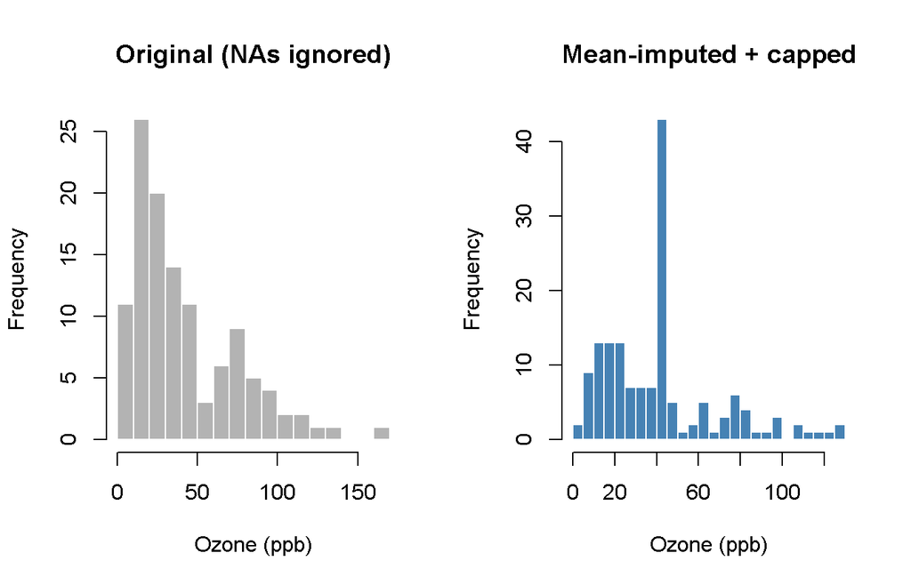

```r
par(mfrow = c(1, 2))
hist(airquality$Ozone, breaks = 20, col = "grey70", border = "white",
     main = "Original (NAs ignored)", xlab = "Ozone (ppb)")
hist(clean_mean$Ozone, breaks = 20, col = "steelblue", border = "white",
     main = "Mean-imputed + capped", xlab = "Ozone (ppb)")
```

```r
par(mfrow = c(1, 1))
```

Notice the spike at the mean in the right-hand histogram: mean imputation reduces variance. That is a real trade-off to weigh when choosing the `method` argument.